# 9. PSPACE

9. PSPACE

WU Xiaokun 吴晓堃

xkun.wu [at] gmail

2021/11/26

## Geography game

**Geography**. Alice names capital city $c$ of country she is in. Bob names a capital city $c'$ that starts with letter on which $c$ ends. Alice and Bob repeat this game until one player is unable to continue.  
**Q**. Does Alice have a forced win?

**Ex**. Budapest $\rightarrow$ Tokyo $\rightarrow$ Ottawa $\rightarrow$ Ankara $\rightarrow$ Amsterdam $\rightarrow$ Moscow $\rightarrow$ Washington $\rightarrow$ etc.

**Geography on graphs**. Given a digraph $G = (V, E)$ and a start node $s$, two players alternate turns by following, if possible, an edge leaving current node to an unvisited node. Can first player guarantee to make the last legal move?

**Remark**. Some problems (especially involving 2-player games and AI) defy classification according to $\mathcal{P}$, EXPTIME, $\mathcal{NP}$, and $\mathcal{NP}$-complete.

# PSPACE complexity class

## PSPACE

**$\mathcal{P}$**. Decision problems solvable in polynomial *time*.

**PSPACE**. Decision problems solvable in polynomial *space*.

**Observation**. $\mathcal{P} \subseteq$ PSPACE.

- Both are asymptotic growth rate
- poly-time algorithm can consume only polynomial space

## PSPACE: facts

**Binary counter**. Count from $0$ to $2^n - 1$ in binary.  
**Algorithm**. Use $n$-bit “odometer”.

- exponential time, polynomial space
- space can be *reused*

**Claim**. 3-SAT $\in$ PSPACE.  
**Pf**.

- Enumerate all $2^n$ possible truth assignments using single $n$-bit counter.
- Check each assignment to see if it satisfies all clauses, reuse space.

**Theorem**. $\mathcal{NP} \subseteq$ PSPACE.  
**Pf**. Consider arbitrary problem $Y \in \mathcal{NP}$.

- Since 3-SAT is $\mathcal{NP}$-complete, $Y \le_P$ 3-SAT,
- Can implement black box in poly-space.

## Various classes of problems

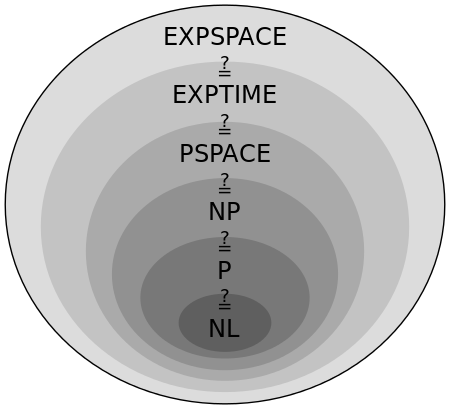

# Quantified satisfiability

## Quantified satisfiability

**QSAT**. Let $\Phi(x_1, .., x_n)$ be a boolean CNF formula. Is the following propositional formula true?

$$\exists x_1 \forall x_2 \exists x_3 \forall x_4 \ldots \exists x_{n-1}
\forall x_n \Phi(x_1, .., x_n),\ \text{assume $n$ is odd}$$

**Intuition**. Amy picks truth value for $x_1$, then Bob for $x_2$, then Amy for $x_3$, and so on. Can Amy satisfy $\Phi$ no matter what Bob does?

**Ex**. $(x_1 \vee x_2) \wedge (x_2 \vee \bar{x_3}) \wedge (\bar{x_1} \vee \bar{x_2} \vee x_3)$  
**Yes**. Amy sets $x_1$ true; Bob sets $x_2$; Amy sets $x_3$ to be same as $x_2$.

**Ex**. $(x_1 \vee x_2) \wedge (\bar{x_2} \vee \bar{x_3}) \wedge (\bar{x_1} \vee \bar{x_2} \vee x_3)$  
**No**. If Amy sets $x_1$ false; Bob sets $x_2$ false; Amy loses;  
**No**. if Amy sets $x_1$ true; Bob sets $x_2$ true; Amy loses.

## Q-SAT $\in$ PSPACE

**Theorem**. Q-SAT $\in$ PSPACE.  
**Pf**. Recursively try all possibilities.

- Only need one bit of information from each subproblem.
- Amount of space is proportional to depth of function call stack.

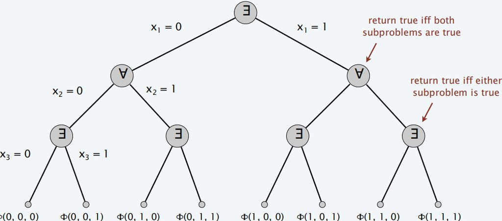

# Planning problem

## 15-puzzle

**8-puzzle, 15-puzzle**. [Noyes Chapman 1874]

- Board: 3-by-3 grid of tiles labeled $1 .. 8$.
- Legal move: slide neighboring tile into blank (white) square.
- Find sequence of legal moves to transform initial configuration into goal configuration.

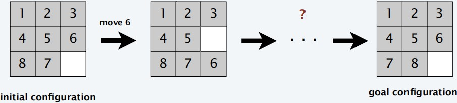

## Planning problem

**Conditions**. Set $C = \{ C_1, .., C_n \}$.  
**Initial configuration**. Subset $c_0 \subseteq C$ of conditions initially satisfied.  
**Goal configuration**. Subset $c^\ast \subseteq C$ of conditions we seek to satisfy.  
**Operators**. Set $O = \{ O_1, .., O_k \}$.

- To invoke operator $O_i$, must satisfy certain prereq conditions.
- After invoking $O_i$ certain conditions become true, and certain conditions become false.

**PLANNING**. Is it possible to apply sequence of operators to get from initial configuration to goal?

**Examples**.

- 15-puzzle. Rubik’s cube.
- Logistical operations to move people, equipment, and materials.

## Planning problem: 8-puzzle

**Planning example**. Can we solve the 8-puzzle?

**Conditions**. $C_{ij}, 1 \le i, j \le 9$: tile $i$ is in square $j$.  
**Initial state**. $c_0 = \{ C_{11}, C_{22}, .., C_{66}, C_{78}, C_{87}, C_{99} \}$.  
**Goal state**. $c^\ast = \{ C_{11}, C_{22}, .., C_{66}, C_{77}, C_{88}, C_{99} \}$.  
**Operators**.

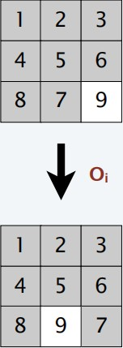

**Solution**. No solution to 8-puzzle or 15-puzzle!

## Diversion: Why is 8-puzzle unsolvable?

**8-puzzle invariant**. Any legal move preserves the *parity* of the number of pairs of pieces in reverse order (**inversions**).

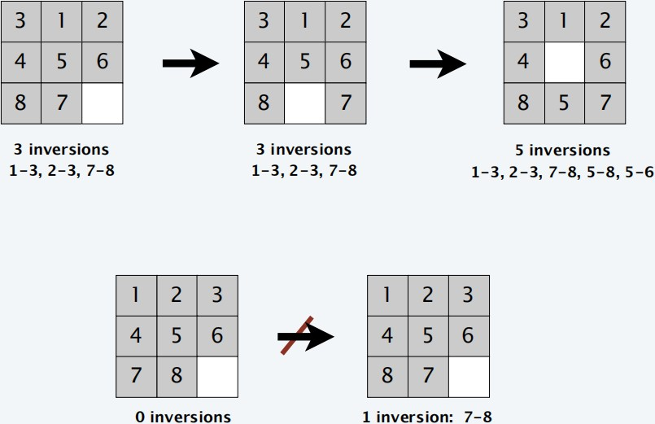

## Planning problem: binary counter

**Planning example**. Can we increment an $n$-bit counter from the all-zeroes state to the all-ones state?

**Conditions**. $C_1, .., C_n$: $C_i$ corresponds to bit-$i$ = 1.  
**Initial state**. $c_0 = \emptyset$: all 0s.  
**Goal state**. $c^\ast = \{ C_1, .., C_n \}$: all 1s.  
**Operators**. $O_1, .., O_n$.

- To invoke operator $O_i$, must satisfy $C_1, .., C_{i–1}$: $i-1$ least significant bits are 1.
- After invoking $O_i$, condition $C_i$ becomes true: set bit $i$ to 1.
- After invoking $O_i$, conditions $C_1, .., C_{i–1}$ become false: set $i-1$ least significant bits to 0.

**Solution**. $\{ \} \Rightarrow \{C_1\} \Rightarrow \{C_2\} \Rightarrow \{C_1, C_2\} \Rightarrow \{C_3\} \Rightarrow \{C_3, C_1\} \Rightarrow ..$

**Observation**. Any solution requires at least $2^n - 1$ steps.

## PLANNING $\in$ EXPTIME

**Configuration graph G**.

- Include node for each of $2^n$ possible configurations.
- Include an edge from configuration $c'$ to configuration $c''$ if one of the operators can convert from $c'$ to $c''$.

**PLANNING**. Is there a path from $c_0$ to $c^\ast$ in configuration graph?

**Claim**. PLANNING $\in$ EXPTIME.  
**Pf**. Run BFS to find path from $c_0$ to $c^\ast$ in configuration graph.

**Note**. Configuration graph can have $2^n$ nodes, and shortest path can be of length = $2^n - 1$ (binary counter).

## PLANNING $\in$ PSPACE

**Theorem**. PLANNING $\in$ PSPACE.  
**Pf**.

- Suppose there is a path from $c_1$ to $c_2$ of length $L$.
- Path from $c_1$ to midpoint and from $c_2$ to midpoint are each $\le L / 2$.
- Enumerate all possible midpoints.
- Apply recursively. Depth of recursion $= \log_2 L$.

`hasPath`($c_1, c_2, L$)

1. if ($L ≤ 1$) return correct answer;
2. foreach configuration $c'$
   1. $x$ = `hasPath`($c_1, c', L/2$);
   2. $y$ = `hasPath`($c_2, c', L/2$);
   3. if ($x$ and $y$) return true;
3. return false;

# PSPACE-complete

## PSPACE-complete

**PSPACE**. Decision problems solvable in polynomial space.

**PSPACE-complete**. Problem $Y \in$ PSPACE-complete if (i) $Y \in$ PSPACE and (ii) for every problem $X \in$ PSPACE, $X \le_P Y$.

- “hardest” PSPACE-complete problem

**Theorem**. [Stockmeyer–Meyer 1973] QSAT $\in$ PSPACE-complete.

**Theorem**. PSPACE $\subseteq$ EXPTIME.  
**Pf**. Previous algorithm solves QSAT in exponential time; and QSAT is PSPACE-complete.

**Summary**. $\mathcal{P}$ $\subseteq$ $\mathcal{NP}$ $\subseteq$ PSPACE $\subseteq$ EXPTIME.

- it is known that $\mathcal{P} \ne$ EXPTIME, but unknown which inclusion is strict;
- conjectured that all are

## PSPACE-complete problems

**More PSPACE-complete problems**.

- **Competitive facility location**.
- Natural generalizations of games.
- Given a memory restricted Turing machine, does it terminate in at most $k$ steps?
- Do two regular expressions describe different languages?
- Is it possible to move and rotate complicated object with attachments through an irregularly shaped corridor?
- Is a deadlock state possible within a system of communicating processors?

## Competitive facility location

**Input**. Graph $G = (V, E)$ with positive edge weights, and target $B$.  
**Game**. Two competing players alternate in selecting nodes. Not allowed to select a node if any of its neighbors has been selected.

**Competitive facility location**. Can second player guarantee at least $B$ units of profit?

## COMPETITIVE-LOC $\in$ PSPACE-complete

**Claim**. COMPETITIVE-FACILITY-LOCATION $\in$ PSPACE-complete.  
**Pf**.

## COMPETITIVE-LOC $\in$ PSPACE-complete

**Construction**. Given instance $\Phi(x_1, .., x_n) = C_1 \wedge C_1 \wedge .. \wedge C_k$ of Q-SAT.

- Include a node for each literal and its negation and connect them. (at most one of $x_i$ and its negation can be chosen)
- Choose $c \ge k + 2$, and put weight $c^i$ on literal $x_i$ and its negation; set $B = c^{n–1} + c^{n–3} + .. + c^4 + c^2 + 1$. (ensures variables are selected in order $x_n, x_{n–1}, .., x_1$)
- As is, player 2 will lose by 1 unit: $c^{n–1} + c^{n–3} + .. + c^4 + c^2$.

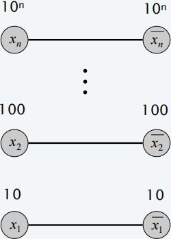

## COMPETITIVE-LOC $\in$ PSPACE-complete

**Construction**. Given instance $\Phi(x_1, .., x_n) = C_1 \wedge C_1 \wedge .. \wedge C_k$ of Q-SAT.

- Give player 2 one last move on which she can try to win.
- For each clause $C_j$, add node with value 1 and an edge to each of its literals.
- Player 2 can make last move iff truth assignment defined alternately by the players failed to satisfy some clause.

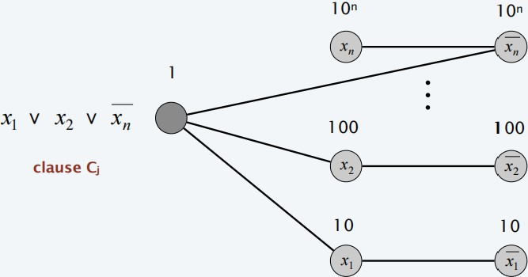